# Code supplement to linear models slides

DATA 299: Sports Analytics - Hitchman

# Simple Linear Regression

## Toy model

See the R practice 6 for creating an actual simple linear model from synthetic data.

## Are batters more successful if they see more pitches?

We can import 2024 data directly from a baseballsavant.mlb.com, as demonstrated in class. Among other things, the dataframe `df` below provides total plate appearances, total pitches seen, as well as hitting performance statistics such as batting average, woba, and hard hit percentage. `df` includes only hitters with at least 400 plate appearances in 2024.

Here’s a quick look:

```r
head(df,5)
```

```
##               Name  pa pitches_per_PA   AVG  woba xwoba hard_hit_percent
## 1 Butler, Lawrence 451       4.024390 0.262 0.345 0.339             47.4
## 2  Reynolds, Bryan 692       3.763006 0.275 0.343 0.350             45.4
## 3     Lopez, Nicky 445       3.658427 0.241 0.275 0.268             16.9
## 4     García, Luis 528       3.566288 0.282 0.328 0.331             41.7
## 5    O'Hearn, Ryan 494       3.886640 0.264 0.330 0.351             40.1
```

### Does pitches per plate appearance associate with batting average?

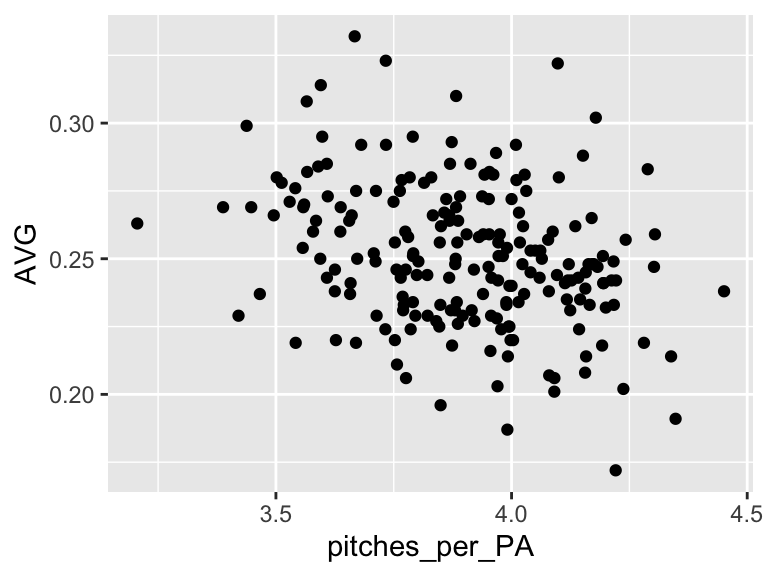

```r
p <- ggplot(df,aes(x = pitches_per_PA,y=AVG))+
  geom_point()
p
```

```r
fit <- lm(AVG ~ pitches_per_PA, data = df)
fit$coefficients # extract slope and y-intercept of least-squares line
```

```
##    (Intercept) pitches_per_PA
##     0.39297792    -0.03644287
```

```r
summary(fit) # much info about model!
```

```
##
## Call:
## lm(formula = AVG ~ pitches_per_PA, data = df)
##
## Residuals:
##       Min        1Q    Median        3Q       Max
## -0.067155 -0.018569  0.000404  0.014282  0.078365
##
## Coefficients:
##                 Estimate Std. Error t value Pr(>|t|)
## (Intercept)     0.392978   0.030910  12.713  < 2e-16 ***
## pitches_per_PA -0.036443   0.007914  -4.605 7.23e-06 ***
## ---
## Signif. codes:  0 '***' 0.001 '**' 0.01 '*' 0.05 '.' 0.1 ' ' 1
##
## Residual standard error: 0.02506 on 205 degrees of freedom
## Multiple R-squared:  0.09375,    Adjusted R-squared:  0.08933
## F-statistic: 21.21 on 1 and 205 DF,  p-value: 7.231e-06
```

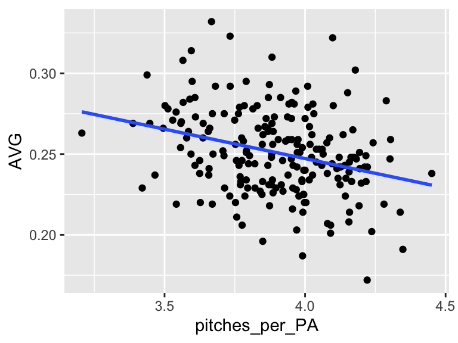

```r
p + geom_smooth(method = 'lm', formula = y ~ x, se=FALSE)
```

### Does pitches per plate appearance associate with woba?

```r
p <- ggplot(df,aes(x = pitches_per_PA,y=woba))+geom_point()

fit <- lm(woba ~ pitches_per_PA, data = df)

summary(fit)
```

```
##
## Call:
## lm(formula = woba ~ pitches_per_PA, data = df)
##
## Residuals:
##      Min       1Q   Median       3Q      Max
## -0.05252 -0.02068 -0.00188  0.01456  0.15079
##
## Coefficients:
##                Estimate Std. Error t value Pr(>|t|)
## (Intercept)     0.25821    0.03954   6.531 5.06e-10 ***
## pitches_per_PA  0.01635    0.01012   1.615    0.108
## ---
## Signif. codes:  0 '***' 0.001 '**' 0.01 '*' 0.05 '.' 0.1 ' ' 1
##
## Residual standard error: 0.03206 on 205 degrees of freedom
## Multiple R-squared:  0.01256,    Adjusted R-squared:  0.007747
## F-statistic: 2.608 on 1 and 205 DF,  p-value: 0.1078
```

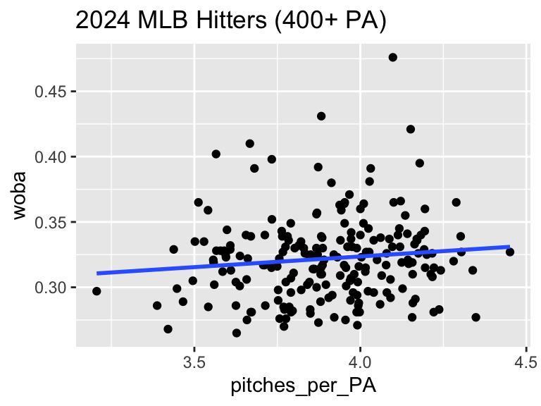

```r
p +
  geom_smooth(method = 'lm', formula = y ~ x, se=FALSE) +
  ggtitle("2024 MLB Hitters (400+ PA)")
```

### Does pitches per plate appearance associate with hard hit percentage?

```r
p <- ggplot(df,aes(x = pitches_per_PA,y=hard_hit_percent))+geom_point()

fit <- lm(hard_hit_percent ~ pitches_per_PA, data = df)

summary(fit)
```

```
##
## Call:
## lm(formula = hard_hit_percent ~ pitches_per_PA, data = df)
##
## Residuals:
##      Min       1Q   Median       3Q      Max
## -22.0951  -4.5741   0.2062   4.9252  19.4902
##
## Coefficients:
##                Estimate Std. Error t value Pr(>|t|)
## (Intercept)      12.614      9.254   1.363  0.17434
## pitches_per_PA    7.211      2.369   3.044  0.00264 **
## ---
## Signif. codes:  0 '***' 0.001 '**' 0.01 '*' 0.05 '.' 0.1 ' ' 1
##
## Residual standard error: 7.503 on 205 degrees of freedom
## Multiple R-squared:  0.04324,    Adjusted R-squared:  0.03857
## F-statistic: 9.264 on 1 and 205 DF,  p-value: 0.002643
```

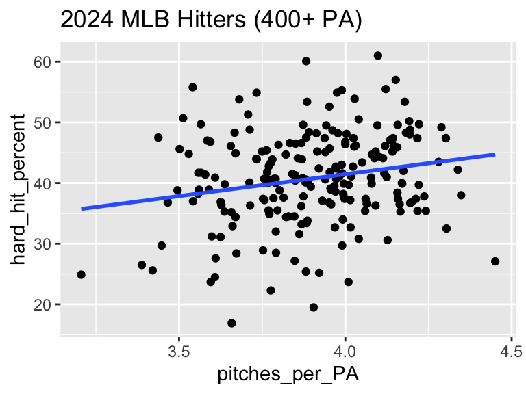

```r
p +
  geom_smooth(method = 'lm', formula = y ~ x, se=FALSE) +
  ggtitle("2024 MLB Hitters (400+ PA)")
```

As an aside, hard hit percentage associates with xwoba!

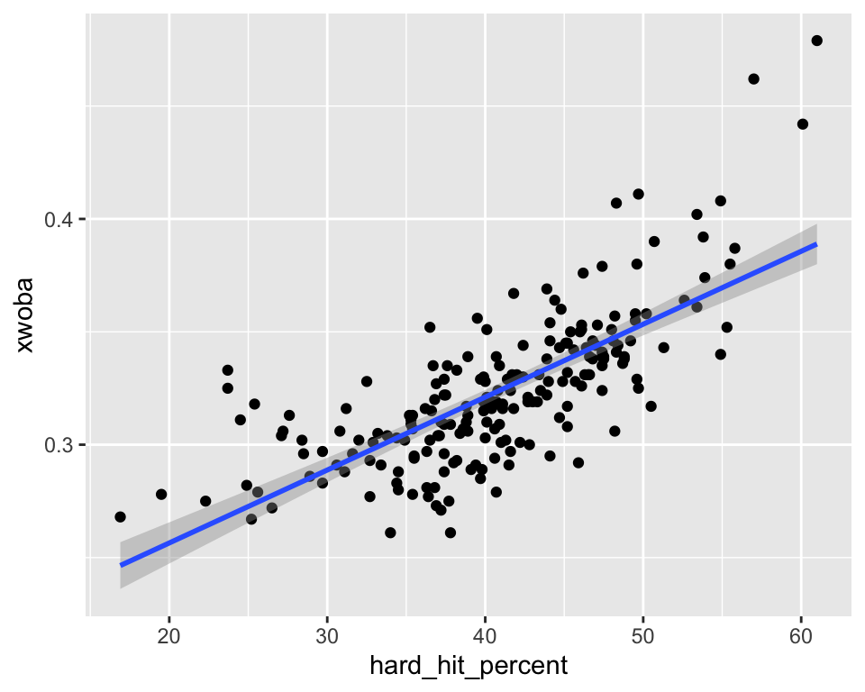

```r
ggplot(df,aes(x=hard_hit_percent, y = xwoba))+
  geom_point()+
  geom_smooth(method = 'lm', formula = y ~ x)
```

```r
linear_fit <- lm(xwoba ~ hard_hit_percent, data = df)
summary(linear_fit)
```

```
##
## Call:
## lm(formula = xwoba ~ hard_hit_percent, data = df)
##
## Residuals:
##       Min        1Q    Median        3Q       Max
## -0.052973 -0.011610 -0.002079  0.009377  0.090092
##
## Coefficients:
##                   Estimate Std. Error t value Pr(>|t|)
## (Intercept)      0.1918812  0.0086920   22.08   <2e-16 ***
## hard_hit_percent 0.0032300  0.0002097   15.40   <2e-16 ***
## ---
## Signif. codes:  0 '***' 0.001 '**' 0.01 '*' 0.05 '.' 0.1 ' ' 1
##
## Residual standard error: 0.02303 on 205 degrees of freedom
## Multiple R-squared:  0.5364, Adjusted R-squared:  0.5341
## F-statistic: 237.2 on 1 and 205 DF,  p-value: < 2.2e-16
```

## NFL Point Differential and Team Wins

The following code loads team info from a csv file linked on our course resource page, then makes a point plot. Team labels are added using the `geom_text_repel()` command which uses the `ggrepel` library.

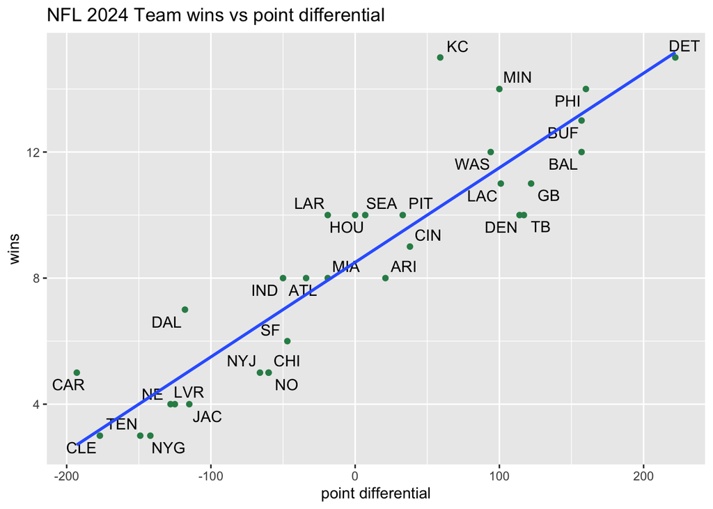

```r
nfl24 <- read.csv("https://mphitchman.com/stats/sports/data/nfl24_standings.csv")

ggplot(nfl24,aes(x = PD, y = W))+
  geom_text_repel(aes(label = Tm))+
  geom_point(col='seagreen')+
  geom_smooth(method='lm', formula=y~x, se = FALSE)+
  labs(x = 'point differential',
       y = 'wins',
       title = 'NFL 2024 Team wins vs point differential')
```

```r
cor(nfl24$W,nfl24$PD)
```

```
## [1] 0.9073223
```

```r
model <- lm(W ~ PD, data = nfl24)
summary(model)
```

```
##
## Call:
## lm(formula = W ~ PD, data = nfl24)
##
## Residuals:
##     Min      1Q  Median      3Q     Max
## -2.0106 -1.1377 -0.3706  0.7745  4.7297
##
## Coefficients:
##             Estimate Std. Error t value Pr(>|t|)
## (Intercept) 8.500000   0.280071   30.35  < 2e-16 ***
## PD          0.030005   0.002538   11.82 8.13e-13 ***
## ---
## Signif. codes:  0 '***' 0.001 '**' 0.01 '*' 0.05 '.' 0.1 ' ' 1
##
## Residual standard error: 1.584 on 30 degrees of freedom
## Multiple R-squared:  0.8232, Adjusted R-squared:  0.8173
## F-statistic: 139.7 on 1 and 30 DF,  p-value: 8.13e-13
```

# Building a quadratic model

## Toy example

We can build a model in which `y` is related to `x` by a quadratic function (plus some random noise).

```r
n = 80
x = runif(n, 0 , 5)
epsilon <- rnorm(n,0,1.4)
y = 0.5*x*x + 2*x + epsilon
df <- data.frame(x = x,
                 y = y)
```

If we encounter these data in the wild, we may start with a linear model:

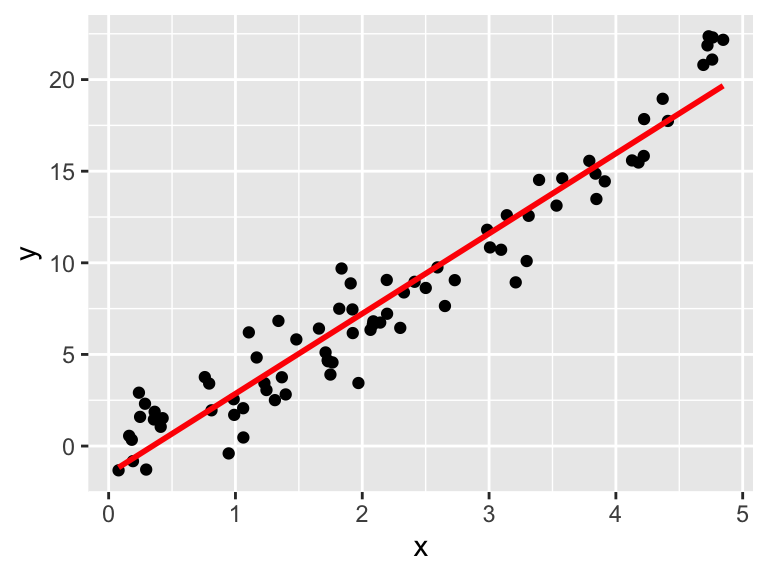

```r
ggplot(df,aes(x = x, y = y))+
  geom_point()+
  geom_smooth(method = 'lm', formula = y~x, col = 'red', se = F)
```

And a quick residual plot may reveal a curved pattern, that suggests a quadratic fit may be an improvement. Is it?

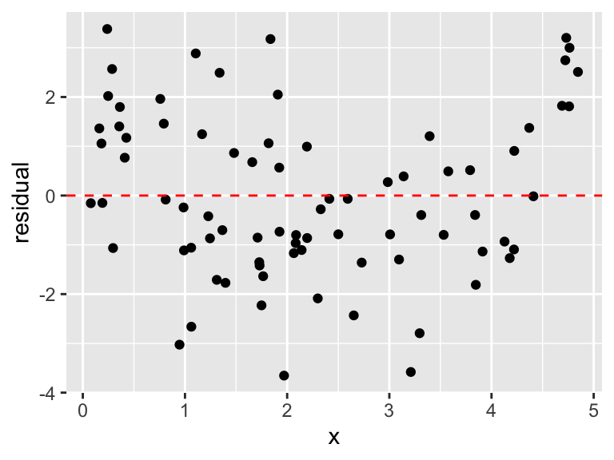

```r
fit <- lm(y ~ x)
ggplot(data.frame(x,residual = fit$residuals), aes(x=x, y = residual))+
  geom_point()+
  geom_hline(yintercept = 0, linetype = 'dashed', col = 'red')
```

```r
model <- lm(y~x, data = df)
summary(model)
```

```
##
## Call:
## lm(formula = y ~ x, data = df)
##
## Residuals:
##     Min      1Q  Median      3Q     Max
## -3.6544 -1.1074 -0.1983  1.2152  3.3802
##
## Coefficients:
##             Estimate Std. Error t value Pr(>|t|)
## (Intercept)  -1.5114     0.3516  -4.299 4.92e-05 ***
## x             4.3691     0.1349  32.387  < 2e-16 ***
## ---
## Signif. codes:  0 '***' 0.001 '**' 0.01 '*' 0.05 '.' 0.1 ' ' 1
##
## Residual standard error: 1.68 on 78 degrees of freedom
## Multiple R-squared:  0.9308, Adjusted R-squared:  0.9299
## F-statistic:  1049 on 1 and 78 DF,  p-value: < 2.2e-16
```

```r
model2 <- lm(y~x + I(x^2), data = df)

summary(model2)
```

```
##
## Call:
## lm(formula = y ~ x + I(x^2), data = df)
##
## Residuals:
##     Min      1Q  Median      3Q     Max
## -3.1248 -0.9434 -0.0497  0.9162  3.9454
##
## Coefficients:
##             Estimate Std. Error t value Pr(>|t|)
## (Intercept)   0.3257     0.4551   0.716    0.476
## x             2.0878     0.4387   4.759 8.94e-06 ***
## I(x^2)        0.4695     0.0871   5.390 7.45e-07 ***
## ---
## Signif. codes:  0 '***' 0.001 '**' 0.01 '*' 0.05 '.' 0.1 ' ' 1
##
## Residual standard error: 1.441 on 77 degrees of freedom
## Multiple R-squared:  0.9497, Adjusted R-squared:  0.9484
## F-statistic: 727.6 on 2 and 77 DF,  p-value: < 2.2e-16
```

The simplest way to address whether the quadratic fit is an improvement is to decide whether the coefficient of the $x^2$ term is statistically significantly different than 0, which it is, according to the summary. Here’s a plot of the data with the quadratic fit:

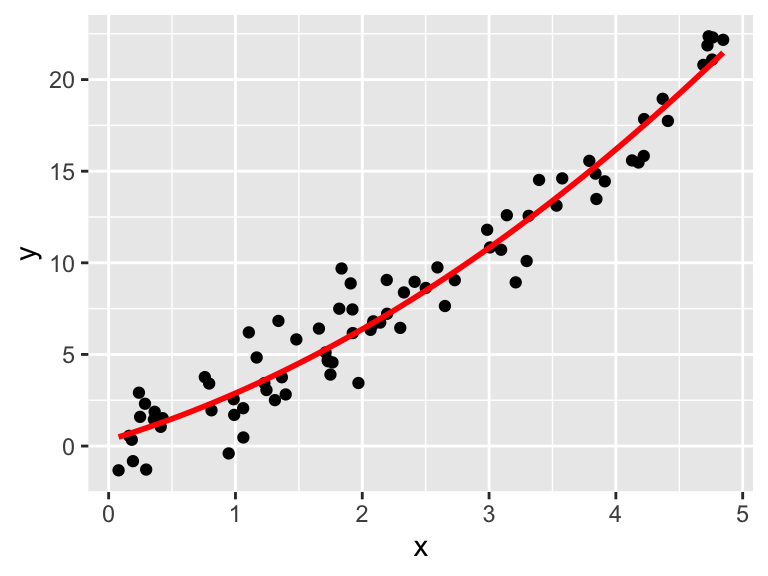

```r
ggplot(df, aes(x = x, y = y))+
  geom_point()+
  stat_smooth(method='lm', formula=y~x+I(x^2), col = 'red', se = FALSE)
```

## Career Trajectory in MLB (Ch 7 of ABDR3e)

We use the tidyverse and Lahman packages to run the code below.

First we load the batting data and create a `get_stats()` function to extract a player’s age each season as well as their home run rate and a few other statistics.

```r
batting <- Batting |>
  replace_na(list(SF = 0, HBP = 0))

get_stats <- function(player_id) {
  batting |>
    filter(playerID == player_id) |>
    inner_join(People, by = "playerID") |>
    mutate(
      birthyear = if_else(
        birthMonth >= 7, birthYear + 1, birthYear
      ),
      Age = yearID - birthyear,
      SLG = (H + X2B + 2 * X3B + 3 * HR) / AB,
      OBP = (H + BB + HBP) / (AB + BB + HBP + SF),
      OPS = SLG + OBP,
      HRpct = HR / AB
    ) |>
    select(Age, SLG, OBP, OPS,HRpct)
}
```

Load a few careers

```r
ruth <- get_stats("ruthba01")
mantle <- get_stats("mantlmi01")
mays <- get_stats("mayswi01")
griff <- get_stats("griffke02")

all4 <- rbind(ruth |> mutate(player='Ruth'),
              mantle |> mutate(player='Mantle'),
              mays |> mutate(player = 'Mays'),
              griff |> mutate(player="Griffey"))
```

Let’s look at each player’s season home run rate by age

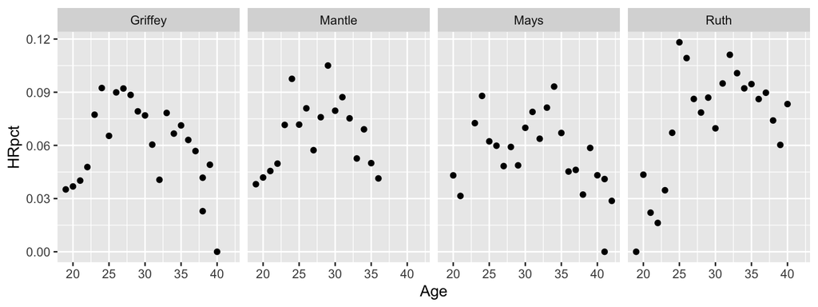

```r
ggplot(all4,aes(x=Age,y=HRpct))+
  geom_point()+
  facet_grid(.~player)
```

The following function fits a quadratic model to a given player’s HRpct stats by age.

```r
fit_model <- function(d) {
  fit <- lm(HRpct ~ I(Age - 30) + I((Age - 30)^2), data = d)
  b <- coef(fit)
  Age_max <- 30 - b[2] / b[3] / 2
  Max <- b[1] - b[2] ^ 2 / b[3] / 4
  list(fit = fit, Age_max = Age_max, Max = Max)
}
```

Build the model for Ken Griffey Jr.

```r
F2 <- fit_model(griff)
F2 |>
  pluck("fit") |>
  coef()
```

```
##     (Intercept)     I(Age - 30) I((Age - 30)^2)
##    0.0808064088   -0.0013150766   -0.0005129373
```

Peak HR_pct and age, predicted by the model:

```r
c(F2$Age_max, F2$Max)
```

```
## I(Age - 30) (Intercept)
## 28.71809219  0.08164931
```

A visual:

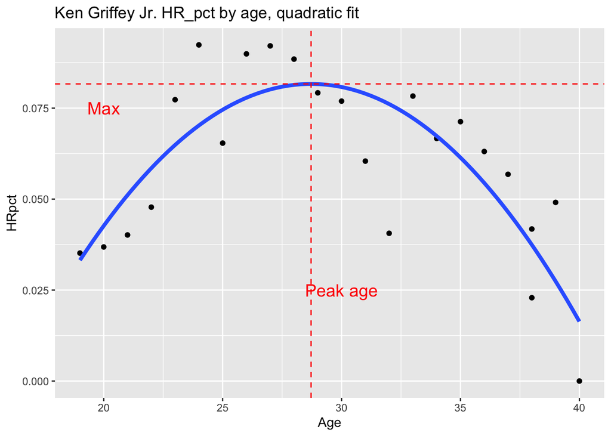

```r
ggplot(griff, aes(x = Age, y = HRpct)) + geom_point() +
  geom_smooth(
    method = "lm", se = FALSE, linewidth = 1.5,
    formula = y ~ poly(x, 2, raw = TRUE)
  ) +
  geom_vline(
    xintercept = F2$Age_max,
    linetype = "dashed", color = "red"
  ) +
  geom_hline(
    yintercept = F2$Max,
    linetype = "dashed", color = "red"
  ) +
  annotate(
    geom = "text", x = c(30, 20), y = c(0.025, 0.075),
    label = c("Peak age", "Max"), size = 5,
    color = "red"
  ) +
  ggtitle("Ken Griffey Jr. HR_pct by age, quadratic fit")
```

# Revisiting Pythagorean Winning Percentage formula

Recall in baseball, a team’s winning percentage is well approximated by the Pythagorean winning percentage formula:

$$\text{xW%} = \frac{RF^2}{RF^2 +
RA^2}.$$

Here we consider whether we can get a better estimate by adjusting the common power in that formula.

In particular, for baseball (or any other sport), is there a better choice of power $b$?

Assume a team’s actual winning percentage is given by
$$\text{W%} = \frac{RF^b}{RF^b + RA^b}.$$
for some power $b$. We can estimate $b$ from data with simple linear regression as follows.

Assume no ties, so a team’s winning percentage is
$$\text{W%} = \frac{W}{W + L},$$
and it follows that

Let’s look at Severini Exercise 6.6. The data can be loaded via link below.

```r
lax <- read.csv("https://mphitchman.com/stats/sports/data/lacrosse.csv")

# Find best b for Pythag Winpct: F^b/(F^b+A^b)

# Use Y = ln(W/L) and X = ln(F/A); and Y = bX + 0

lax$Y = log(lax$W/lax$L)
lax$X = log(lax$PF/lax$PA)

fit <- lm(Y ~ X, data = lax)

fit$coefficients
```

```
## (Intercept)           X
## -0.01299833  4.98767175
```

Looks like these Lacrosse data suggest the best power $b$ is about 5!

# Multiple Linear Regression

## Toy Example

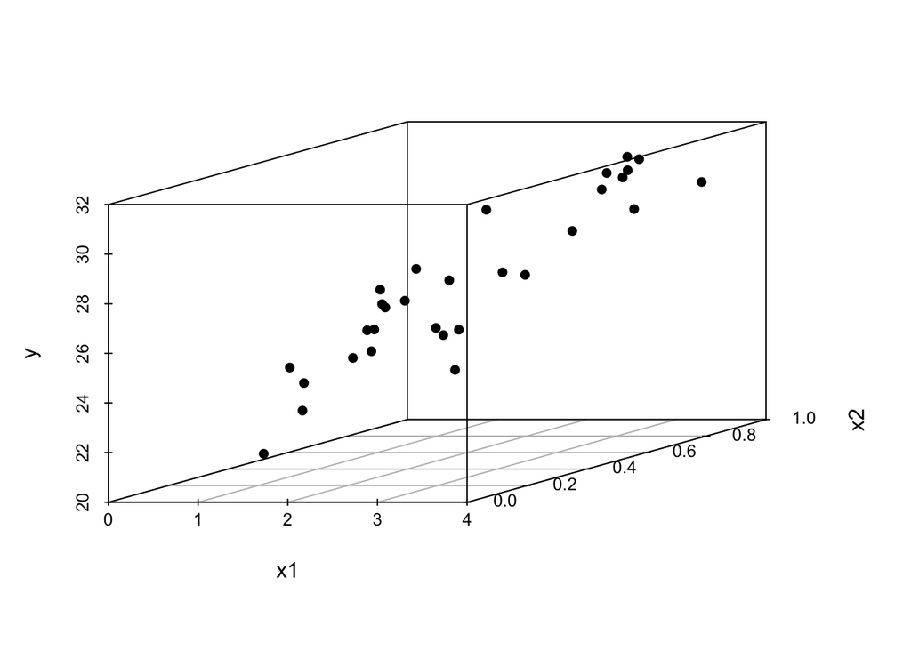

```r
## toy example
x1 <- runif(30,0,4)
x2 <- runif(30,0,1)
epsilon <- rnorm(30,0,1)
y <- 20 + 2*x1 + 5*x2 + epsilon

library(scatterplot3d)
scatterplot3d(x1,x2,y,pch=16,angle = 30)
```

If we ignore `x2` and build a simple linear model relating `x1` to `y`, we find this:

```r
summary(lm(y~x1))
```

```
##
## Call:
## lm(formula = y ~ x1)
##
## Residuals:
##     Min      1Q  Median      3Q     Max
## -4.3123 -1.4053  0.1765  1.5846  3.1947
##
## Coefficients:
##             Estimate Std. Error t value Pr(>|t|)
## (Intercept)  23.7246     0.7442  31.879  < 2e-16 ***
## x1            1.5408     0.3157   4.881 3.84e-05 ***
## ---
## Signif. codes:  0 '***' 0.001 '**' 0.01 '*' 0.05 '.' 0.1 ' ' 1
##
## Residual standard error: 2.034 on 28 degrees of freedom
## Multiple R-squared:  0.4597, Adjusted R-squared:  0.4404
## F-statistic: 23.83 on 1 and 28 DF,  p-value: 3.837e-05
```

How well does the variable `x1` by itself predict values of `y`?

Does are model improve if we include `x2` as well? (Answer: yup!)

```r
summary(lm(y~x1 + x2))
```

```
##
## Call:
## lm(formula = y ~ x1 + x2)
##
## Residuals:
##     Min      1Q  Median      3Q     Max
## -2.1749 -0.7878  0.1529  0.7867  1.6994
##
## Coefficients:
##             Estimate Std. Error t value Pr(>|t|)
## (Intercept)  19.7335     0.6546  30.145  < 2e-16 ***
## x1            1.8867     0.1820  10.369 6.49e-11 ***
## x2            5.6260     0.7120   7.902 1.71e-08 ***
## ---
## Signif. codes:  0 '***' 0.001 '**' 0.01 '*' 0.05 '.' 0.1 ' ' 1
##
## Residual standard error: 1.138 on 27 degrees of freedom
## Multiple R-squared:  0.8369, Adjusted R-squared:  0.8248
## F-statistic: 69.27 on 2 and 27 DF,  p-value: 2.334e-11
```

## Can we predict strikeout rate from Fastball Velocity, Curve Velocity, and Curve Movement?

```r
url <- "https://baseballsavant.mlb.com/leaderboard/custom?year=2024&type=pitcher&filter=&min=200&selections=k_percent%2Cff_avg_speed%2Ccu_avg_speed%2Ccu_avg_break&chart=false&x=k_percent&y=k_percent&r=no&chartType=beeswarm&sort=1&sortDir=asc"
curl <- paste0(url,"&csv=true")
krate <- read.csv(curl)
```

```r
krate <- krate |> remove_missing()
fit <- lm(k_percent ~ ff_avg_speed + cu_avg_speed + cu_avg_break, data = krate)
summary(fit)
```

```
##
## Call:
## lm(formula = k_percent ~ ff_avg_speed + cu_avg_speed + cu_avg_break,
##     data = krate)
##
## Residuals:
##     Min      1Q  Median      3Q     Max
## -9.8739 -2.5933 -0.0135  2.2942 12.4063
##
## Coefficients:
##               Estimate Std. Error t value Pr(>|t|)
## (Intercept)  -73.45264   12.17693  -6.032 7.65e-09 ***
## ff_avg_speed   0.91750    0.16042   5.719 3.83e-08 ***
## cu_avg_speed   0.09223    0.10969   0.841  0.40142
## cu_avg_break   0.18200    0.06781   2.684  0.00788 **
## ---
## Signif. codes:  0 '***' 0.001 '**' 0.01 '*' 0.05 '.' 0.1 ' ' 1
##
## Residual standard error: 3.902 on 201 degrees of freedom
## Multiple R-squared:  0.2437, Adjusted R-squared:  0.2324
## F-statistic: 21.59 on 3 and 201 DF,  p-value: 3.66e-12
```

Looks like curve ball average speed is not statistically significant. That is, our data do not provide strong evidence that the coefficient for curve ball speed is different than 0. So let’s eliminate it:

```r
fit2 <- lm(k_percent ~ ff_avg_speed + cu_avg_break, data = krate)
summary(fit2)
```

```
##
## Call:
## lm(formula = k_percent ~ ff_avg_speed + cu_avg_break, data = krate)
##
## Residuals:
##     Min      1Q  Median      3Q     Max
## -9.6842 -2.5390 -0.0388  2.2125 12.1178
##
## Coefficients:
##               Estimate Std. Error t value Pr(>|t|)
## (Intercept)  -73.42864   12.16807  -6.035 7.50e-09 ***
## ff_avg_speed   0.99836    0.12831   7.781 3.64e-13 ***
## cu_avg_break   0.16215    0.06352   2.553   0.0114 *
## ---
## Signif. codes:  0 '***' 0.001 '**' 0.01 '*' 0.05 '.' 0.1 ' ' 1
##
## Residual standard error: 3.899 on 202 degrees of freedom
## Multiple R-squared:  0.241,  Adjusted R-squared:  0.2335
## F-statistic: 32.08 on 2 and 202 DF,  p-value: 7.976e-13
```

## Including a categorical variable in a regression model

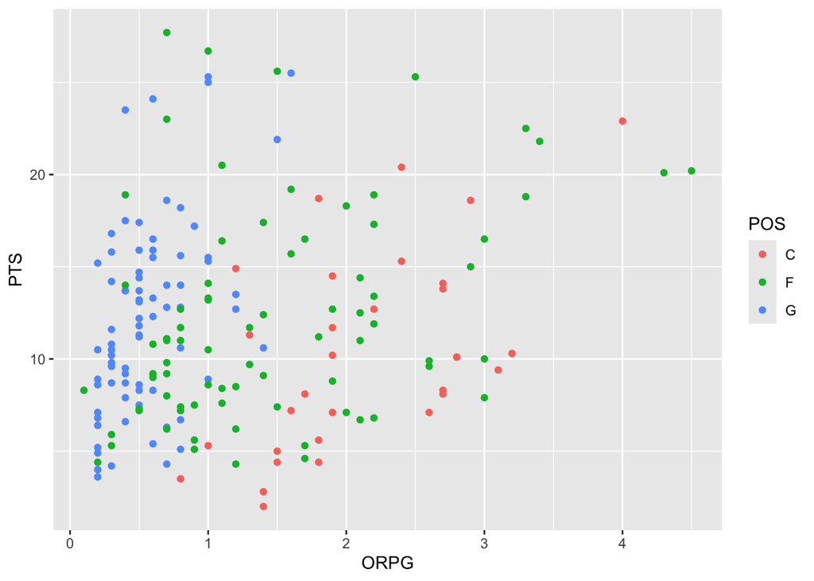

```r
nba <- read.csv("~/Library/CloudStorage/OneDrive-LinfieldUniversity/Spring 25/DATA 299/presentations/linear models/csv/NBA_reb_score.csv")

ggplot(nba,aes(x = ORPG, y = PTS, col = POS))+
  geom_point()
```

```r
summary(lm(PTS ~ ORPG, data = nba))
```

```
##
## Call:
## lm(formula = PTS ~ ORPG, data = nba)
##
## Residuals:
##      Min       1Q   Median       3Q      Max
## -10.1687  -4.0773  -0.6025   3.5068  16.5233
##
## Coefficients:
##             Estimate Std. Error t value Pr(>|t|)
## (Intercept)  10.1846     0.6552  15.545  < 2e-16 ***
## ORPG          1.4172     0.4304   3.292  0.00119 **
## ---
## Signif. codes:  0 '***' 0.001 '**' 0.01 '*' 0.05 '.' 0.1 ' ' 1
##
## Residual standard error: 5.371 on 183 degrees of freedom
## Multiple R-squared:  0.05592,    Adjusted R-squared:  0.05076
## F-statistic: 10.84 on 1 and 183 DF,  p-value: 0.001192
```

Three positions are included in the data frame, center (C), forward (F), and guard (G).

We can convert this categorical variable to numerical variable(s). The code below defines `Pc` to be 1 if that player is a center, and 0 otherwise. Similarly, `Pf` is set to 1 if the player is a forward, and 0 otherwise. In this way, the two columns work together to determine a player’s position (a guard would have Pc = 0 and Pf = 0).

```r
nba <- nba |> mutate(Pc = ifelse(POS == 'C',1,0),
                     Pf = ifelse(POS == 'F',1,0))
```

In general, if categorical variable can take on $n$ values, we can create $n-1$ new binary variables to encode the variable.

Here’s a summary of the model if we take position into account

```r
summary(lm(PTS~ORPG+Pc+Pf, data = nba))
```

```
##
## Call:
## lm(formula = PTS ~ ORPG + Pc + Pf, data = nba)
##
## Residuals:
##     Min      1Q  Median      3Q     Max
## -8.8493 -3.4921 -0.7012  2.6751 17.7988
##
## Coefficients:
##             Estimate Std. Error t value Pr(>|t|)
## (Intercept)  10.5430     0.6545  16.109  < 2e-16 ***
## ORPG          2.9775     0.5289   5.630 6.78e-08 ***
## Pc           -6.5888     1.3590  -4.848 2.67e-06 ***
## Pf           -2.7260     0.9547  -2.855   0.0048 **
## ---
## Signif. codes:  0 '***' 0.001 '**' 0.01 '*' 0.05 '.' 0.1 ' ' 1
##
## Residual standard error: 5.081 on 181 degrees of freedom
## Multiple R-squared:  0.1645, Adjusted R-squared:  0.1506
## F-statistic: 11.88 on 3 and 181 DF,  p-value: 3.888e-07
```

Is a player’s position useful to the model?

We remark that the `lm()` function in R also does this conversion for us directly, saving us the trouble of defining the `Pc` and `Pf` columns (though it might choose its new variables differently):

```r
summary(lm(PTS~ORPG+POS, data = nba))
```

```
##
## Call:
## lm(formula = PTS ~ ORPG + POS, data = nba)
##
## Residuals:
##     Min      1Q  Median      3Q     Max
## -8.8493 -3.4921 -0.7012  2.6751 17.7988
##
## Coefficients:
##             Estimate Std. Error t value Pr(>|t|)
## (Intercept)   3.9542     1.4440   2.738 0.006793 **
## ORPG          2.9775     0.5289   5.630 6.78e-08 ***
## POSF          3.8628     1.1282   3.424 0.000764 ***
## POSG          6.5888     1.3590   4.848 2.67e-06 ***
## ---
## Signif. codes:  0 '***' 0.001 '**' 0.01 '*' 0.05 '.' 0.1 ' ' 1
##
## Residual standard error: 5.081 on 181 degrees of freedom
## Multiple R-squared:  0.1645, Adjusted R-squared:  0.1506
## F-statistic: 11.88 on 3 and 181 DF,  p-value: 3.888e-07
```